# Case Study: Statistical and ML tools

Lara Monteserín Placer

UC3M, 2023/24

# HMW 2

## 1. Introduction

On any given day, cinemas offers a vast array of film, with millions of spectators spending money on it. Understanding the factors that influence total sales is crucial. In this study, we aim to predict the total amount of sales for films in different cinemas by leveraging various features available in the dataset.

Some of the advantages of forecasting future sales are:

- Sales drive everything else and help determine the organisation’s production plan.
- It allows filmmakers to effectively allocate resources for future growth and to manage their finances and contracts.
- It enables ongoing strategic planning: by knowing the rate of future sales, filmmakers can improve pricing, product development and advertising.

[figure not shown]

In this case study, we will use a data set with 142525 instances of films screened in cinemas in 2018.

We took the dataset from Kaggle: https://www.kaggle.com/datasets/arashnic/cinema-ticket/data

### 1.1 The dataset: Description of features

The dataset cinemaTicket_Ref.csv includes the following 14 variables:

1. **film_code**: A unique identifier for each film in the dataset.
2. **cinema_code**: A unique code assigned to each cinema in the dataset.
3. **total_sales**: The total revenue generated from ticket sales for a specific film and cinema.
4. **tickets_sold**: The total number of tickets sold for a particular film and cinema.
5. **tickets_out**: The number of tickets that were distributed or printed for a specific film and cinema.
6. **show_time**: The duration of the film screening in minutes.
7. **occu_perc**: The percentage of occupancy in the cinema during the film screening.
8. **ticket_price**: The price of a single movie ticket.
9. **ticket_use**: The number of tickets used or collected during the film screening.
10. **capacity**: The maximum seating capacity of the cinema.
11. **date**: The date on which the film was screened.
12. **month**: The month in which the film screening occurred.
13. **quarter**: The quarter of the year in which the film screening took place.
14. **day**: The day of the week on which the film was screened.

### 1.2 The goal

Predict the response, the feature total_sales, that represents the total revenue generated from ticket sales for a specific film and cinema, as a function of the other variables using both Statistical and ML tools.

```r
library(tidyverse)
library(MASS)
library(e1071)
library(caret)
library(lubridate)
library(tidytext)

setwd("C:/Users/laram/Desktop/Todo/UC3M/Second Bimester/Models/Assignment2")
cinema <- read.csv("cinemaTicket_Ref.csv")

# Display column names in the dataset
colnames(cinema)
```

```
##  [1] "film_code"    "cinema_code"  "total_sales"  "tickets_sold" "tickets_out"
##  [6] "show_time"    "occu_perc"    "ticket_price" "ticket_use"   "capacity"
## [11] "date"         "month"        "quarter"      "day"
```

```r
#dim(cinema)
#str(cinema)
#summary(cinema)
```

## 2. Data Preparation

### 2.1 Feature extraction

We have created a column ratio_used, representing the number of tickets sold that are finally used.

```r
before_rows <- nrow(cinema)
#print(before_rows)
cinema <- cinema[cinema$ticket_use >= 0, ]
after_rows <- nrow(cinema)
#print(after_rows)

cinema$ratio_used <- cinema$ticket_use / cinema$tickets_sold
```

### 2.2 Data cleaning

We want to ensure that we are working with a reliable and accurate dataset.

Until now, we have 142463 instances.

There are only 2 columns (occu_perc and capacity) with null values and there are 125 null values in each. As this value is very low compared to the size of the dataset, we will just remove those instances, so we keep 142338 instances.

```r
# Counting NAs and empty values in each column
na_counts <- colSums(is.na(cinema) | cinema == "")
na_counts <- na_counts[order(-na_counts)]
#print(na_counts)

# Removing instances with null values
cinema <- cinema[complete.cases(cinema), ]

#Data types
glimpse(cinema)
```

```
## Rows: 142,338
## Columns: 15
## $ film_code    <int> 1492, 1492, 1492, 1492, 1492, 1492, 1492, 1492, 1492, 149…
## $ cinema_code  <int> 304, 352, 489, 429, 524, 71, 163, 450, 51, 522, 43, 529, …
## $ total_sales  <int> 3900000, 3360000, 2560000, 1200000, 1200000, 1050000, 102…
## $ tickets_sold <int> 26, 42, 32, 12, 15, 7, 10, 5, 11, 4, 6, 4, 5, 2, 2, 112, …
## $ tickets_out  <int> 0, 0, 0, 0, 0, 0, 0, 0, 0, 0, 0, 0, 0, 0, 0, 0, 0, 0, 0, …
## $ show_time    <int> 4, 5, 4, 1, 3, 3, 3, 3, 2, 3, 3, 3, 6, 3, 1, 4, 5, 3, 3, …
## $ occu_perc    <dbl> 4.26, 8.08, 20.00, 11.01, 16.67, 0.98, 7.69, 1.57, 0.95, …
## $ ticket_price <dbl> 150000.00, 80000.00, 80000.00, 100000.00, 80000.00, 15000…
## $ ticket_use   <int> 26, 42, 32, 12, 15, 7, 10, 5, 11, 4, 6, 4, 5, 2, 2, 112, …
## $ capacity     <dbl> 610.32864, 519.80198, 160.00000, 108.99183, 89.98200, 714…
## $ date         <chr> "2018-05-05", "2018-05-05", "2018-05-05", "2018-05-05", "…
## $ month        <int> 5, 5, 5, 5, 5, 5, 5, 5, 5, 5, 5, 5, 5, 5, 5, 5, 5, 5, 5, …
## $ quarter      <int> 2, 2, 2, 2, 2, 2, 2, 2, 2, 2, 2, 2, 2, 2, 2, 2, 2, 2, 2, …
## $ day          <int> 5, 5, 5, 5, 5, 5, 5, 5, 5, 5, 5, 5, 5, 5, 5, 4, 4, 4, 4, …
## $ ratio_used   <dbl> 1.0000000, 1.0000000, 1.0000000, 1.0000000, 1.0000000, 1.…
```

```r
#Data transformation to ensure that there are not any leading and trailing whitespaces from all character columns in the dataframe
cinema <- cinema %>% mutate_all(str_trim)

#Standardizing and cleaning column names. Useful for ensuring that column names are consistent and easy to work with.
library(janitor)
cinema <- cinema%>% clean_names()

#Current number of rows
n_rows <- nrow(cinema)
#print(n_rows)

#Creates a logical vector duplicate_rows indicating whether each row in the data frame is a duplicate of a previous row
duplicate_rows <- cinema %>% duplicated.data.frame()

#Retains only the unique rows
library(dplyr)
cinema <- distinct(cinema)

#Number of rows after removing duplicates
n_rows2 <- nrow(cinema)
#print(n_rows2)

# Duplicates based on column "film_code"
cinema1 <- cinema %>% distinct(film_code, .keep_all = TRUE)

# Duplicates based on column "cinema_code"
cinema2 <- cinema %>% distinct(cinema_code, .keep_all = TRUE)

n_rows3 <- nrow(cinema1)
n_rows4 <- nrow(cinema2)
#print(n_rows3)
#print(n_rows4)

#Creating the new ID
cinema$id <- paste(cinema$film_code, cinema$cinema_code, cinema$date, sep="_")

#We know filter by the new id
cinema <- cinema %>% distinct(id, .keep_all = TRUE)

n_rows5 <- nrow(cinema)
#print(n_rows5)
```

### 2.3 Splitting into train and test

It is always a good idea to separate from the beginning the training set (what the tool is going to see) from the testing set (used only to validate predictions).

```r
# split between training and testing sets
spl = createDataPartition(cinema$total_sales, p = 0.8, list = FALSE)
cineTrain = cinema[spl,]
cineTest = cinema[-spl,]

#str(cineTrain)
#summary(cineTrain)
```

## 3. Explanatory Descriptive Analysis (EDA)

We plot variables in order to get information, taking into account the most important variable, that is the target.

### 3.1 Target variable analysis: total sales

We plot a histogram of the target variable. As most of the values are close to zero, we cannot see anything so we apply logarithms to the target.

From the new histogram, we can tell that the distribution is Gaussian.

As there are no values that are zero in the target, we do not need to add any constant to the logarithm.

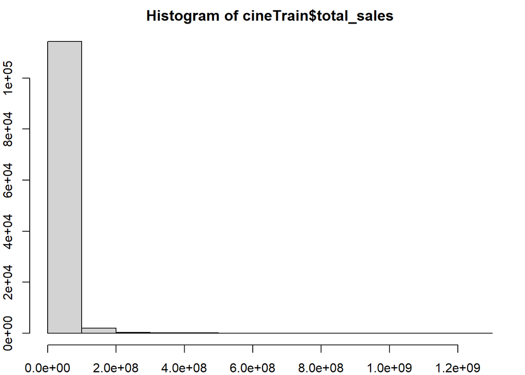

```r
par(mfrow = c(1, 1), mar = c(2, 2, 2, 1))

cineTrain$total_sales <- as.numeric(cineTrain$total_sales)
cineTest$total_sales <- as.numeric(cineTest$total_sales)

#As there are no zeros, there is no danger in calculating log(0) so we do not have to sum any constant
zero_sales_count <- sum(cinema$total_sales == 0)

#Plot the target (use only the train)
hist(cineTrain$total_sales) # option 1
```

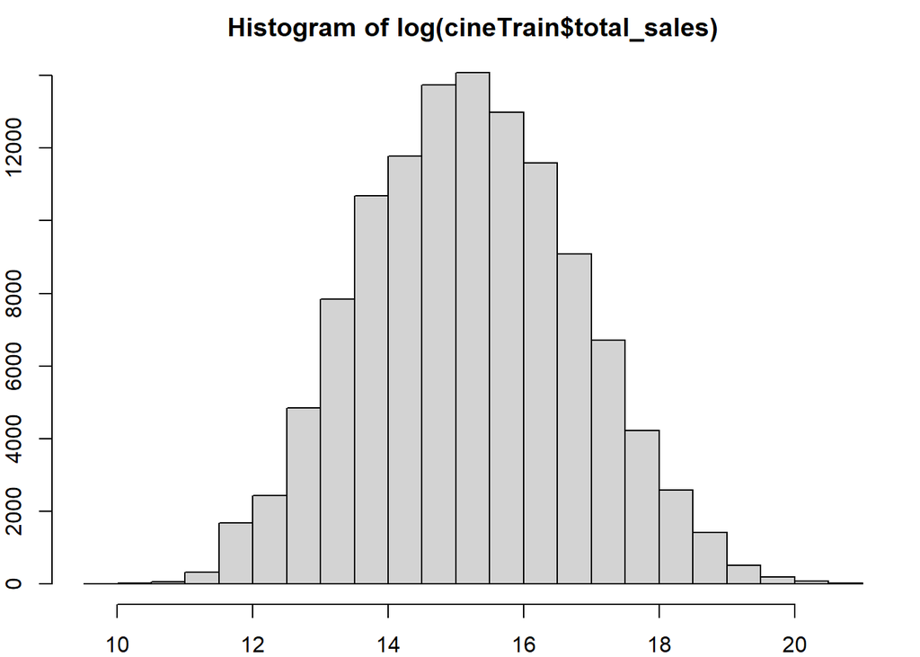

```r
hist(log(cineTrain$total_sales)) # option 2 --> taking logs
```

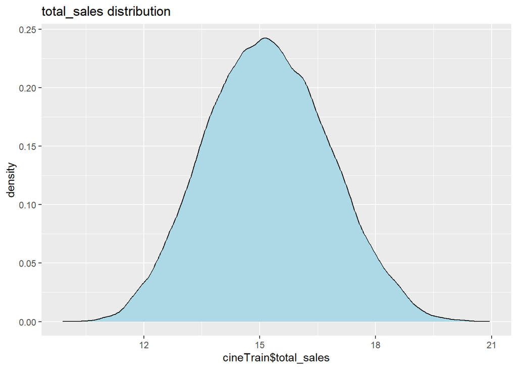

```r
ggplot(cineTrain, aes(log(cineTrain$total_sales))) + geom_density(fill="lightblue") + xlab("cineTrain$total_sales") + ggtitle("total_sales distribution")
```

### 3.2 Other variables analysis respect to the target

#### 3.2.1 Continuous variables

To visualize the relationship between the target and continuous variables, we show scatter plots. To do this correctly, we transform all columns that are of type character although they are in fact numeric, into numeric type.

A positive linear relationship can be discerned with the variables occu_perc and capacity. Also, an exponential/logarithmic (we cannot know it without applying more transformations) relationship can be seen with ticket_price and ratio_used. In any case, there is a positive relationship.

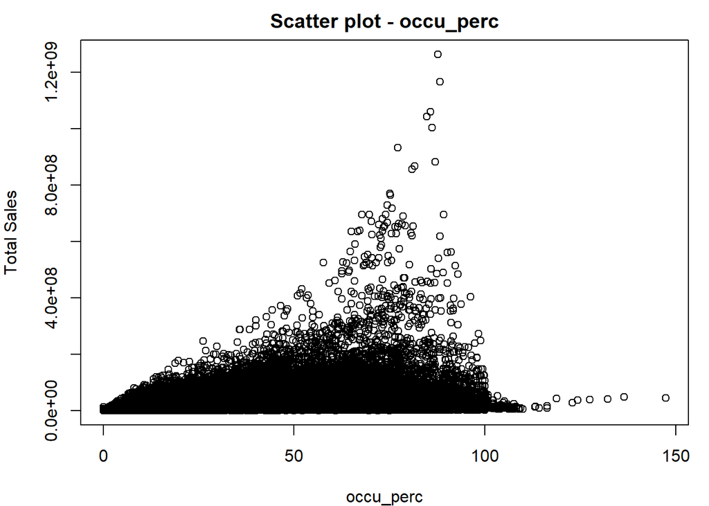

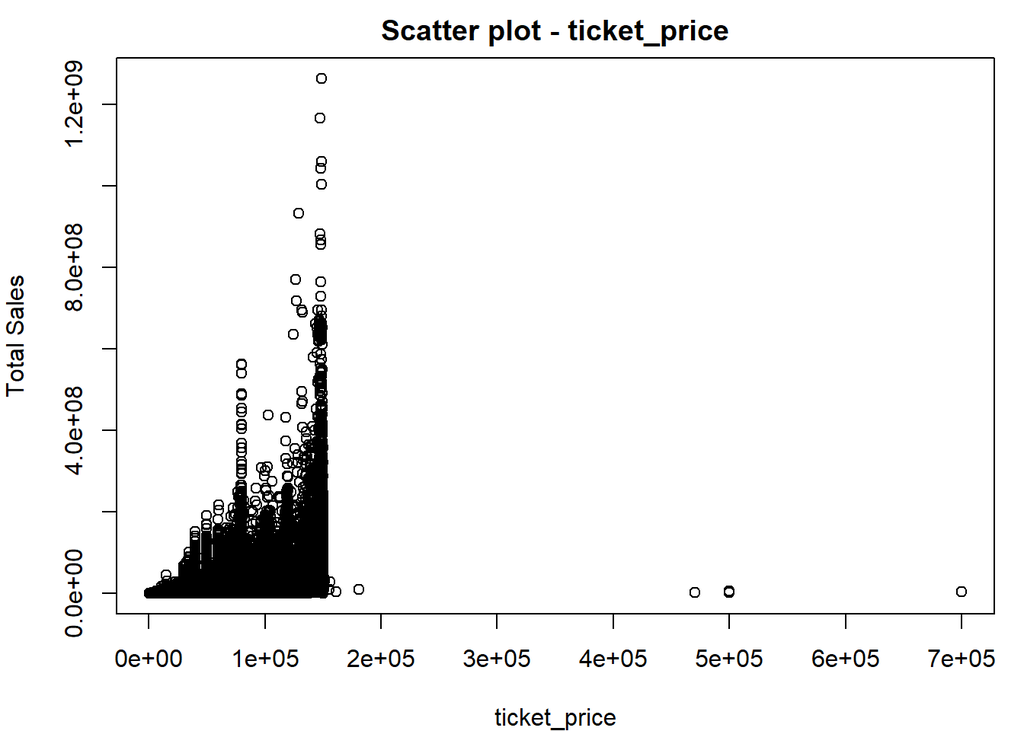

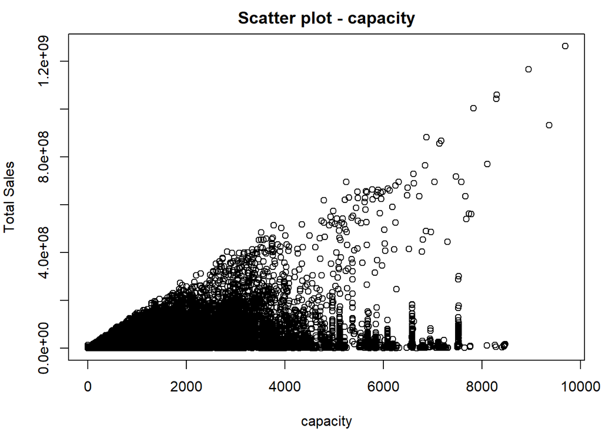

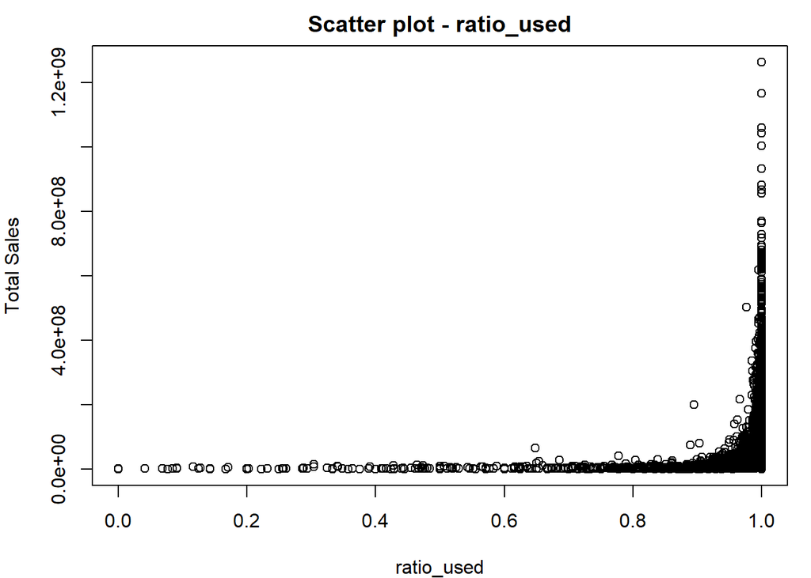

```r
to_exclude <- c("id", "date")

cineTrain <- cineTrain %>%
  mutate_at(vars(-all_of(to_exclude)), as.numeric)

cineTest <- cineTest %>%
  mutate_at(vars(-all_of(to_exclude)), as.numeric)

continuous_vars <- c("occu_perc", "ticket_price", "capacity", "ratio_used")

par(mfrow = c(1, 1), mar = c(4, 4, 2, 1))

for (variable in continuous_vars) {
  plot(cineTrain[[variable]], cineTrain$total_sales,
       xlab = variable, ylab = "Total Sales",
       main = paste("Scatter plot -", variable))
}
```

#### 3.2.2 Discrete variables

We have created barplots for each discrete variable, where the height of each bar represents the average total sales for each value of the discrete variable. We add date although it is not a discrete variable, because it is the only categorical one and a bar plot is enough to see how it behaves.

Looking at the plots, some cases where the scores appear to be higher are:

- For some specific films and cinemas, values are higher
- The higher the number of tickets_sold
- The greater the number of ticket_use
- In the first quarter of the year (also in months 2, 3 and 4 and during the first part of the plot “date”, so it is consistent).

Some other cases where the increase in scores is not so clear are:

- During some days of the month. These are probably Fridays, Saturdays or spectator’s days, but we cannot know it as there is no data that can relate numbers to week days.
- The higher the show_time

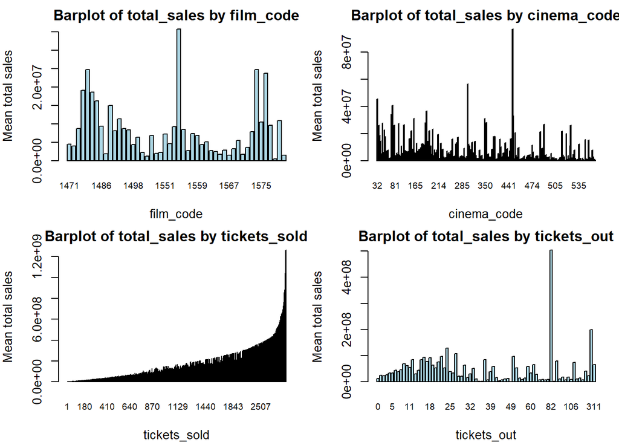

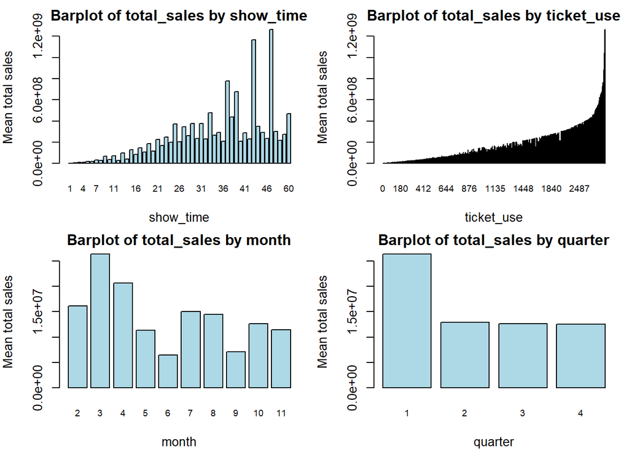

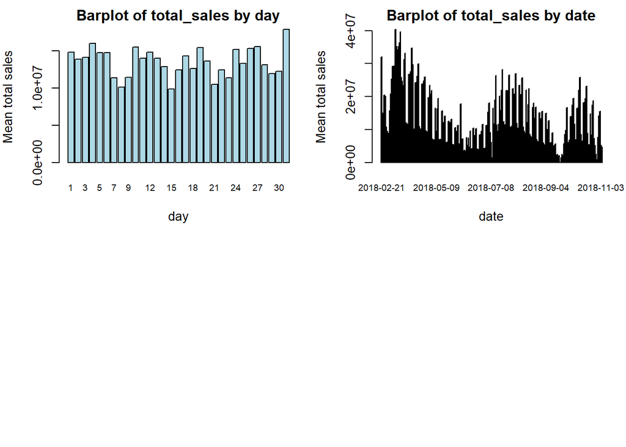

```r
discrete_vars <- c("film_code", "cinema_code", "tickets_sold", "tickets_out", "show_time", "ticket_use", "month", "quarter", "day", "date")

par(mfrow = c(2, 2), mar = c(4, 4, 2, 1))

for (col in discrete_vars) {
  # Barplot
  bar_data <- tapply(cineTrain$total_sales, cineTrain[, col], mean)
  barplot(bar_data, col = "lightblue", main = paste("Barplot of total_sales by", col), xlab = col, ylab = "Mean total sales", cex.names = 0.7)
}
```

### 3.3 Calculating correlations between total sales and other variables

Out of the 15 variables (simple regressions) that we have, we should decide which is he best one to predict (one beta). This variable will be the one that is more correlated with total_sales.

To know which are the most correlated variables with total_sales, we sort the variables by the correlation. The correlation between the target and the target is always 1. We add it so that it scales respect to 1 (with an informative purpose).

To be able to calculate the correlation of the date with the target, we need it to transform its format before. Also, we exclude the ID for the calculation of correlations.

As we just want to do this for extracting correlations, we will create a new cineTrain_corr in order to not modify the original, that we will use to predict.

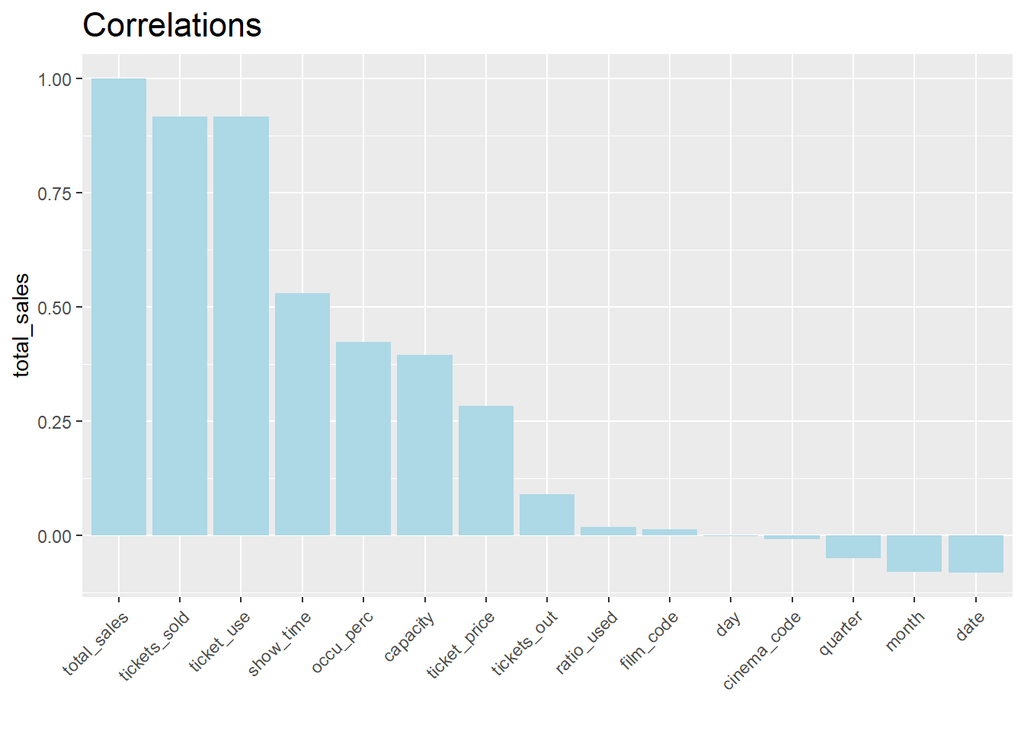

```r
cineTrain_corr <- cineTrain
cineTest_corr <- cineTest

cineTrain_corr$date <- as.Date(cineTrain_corr$date)
cineTest_corr$date <- as.Date(cineTest_corr$date)

cineTrain_corr[, 1:15] <- mutate_all(cineTrain_corr[, 1:15], as.numeric)
#We do the same to the testing set to be able to predict in the future (as the variables have to be of the same type in both parts of the dataframe)
cineTest_corr[, 1:15] <- mutate_all(cineTest_corr[, 1:15], as.numeric)

corr_scores <- sort(cor(cineTrain_corr[, 1:15])["total_sales",], decreasing = T)

corr = data.frame(corr_scores)

corr$abs_corr_scores <- abs(corr_scores)

ggplot(corr, aes(x = row.names(corr), y = corr_scores)) +
  geom_bar(stat = "identity", fill = "lightblue") +
  scale_x_discrete(limits= row.names(corr)) +
  labs(x = "", y = "total_sales", title = "Correlations") +
  theme(plot.title = element_text(hjust = 0, size = rel(1.5)),
        axis.text.x = element_text(angle = 45, hjust = 1))
```

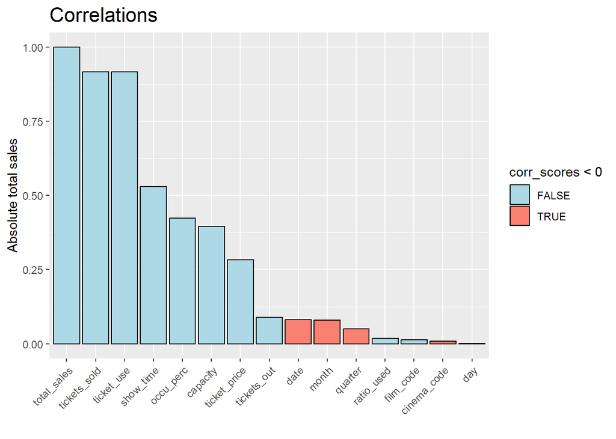

```r
# Reordering the dataframe by absolute values
corr <- corr[order(corr$abs_corr_scores, decreasing = TRUE), ]
ggplot(corr, aes(x = row.names(corr), y = abs_corr_scores, fill = corr_scores < 0)) +
  geom_bar(stat = "identity", color = "black") +
  scale_x_discrete(limits = row.names(corr)) +
  labs(x = "", y = "Absolute total sales", title = "Correlations") +
  scale_fill_manual(values = c("lightblue", "salmon")) +
  theme(plot.title = element_text(hjust = 0, size = rel(1.5)),
        axis.text.x = element_text(angle = 45, hjust = 1))
```

We can see that most of the correlations are quite low, we will not be able to predict very well (sigma squared is high). In any case, there are two features, tickets_sold and ticket_use, that are highly correlated with the target (which is reasonable), and also show_time, occu_perc and capacity seem to be correlated to the target in some way.

## * Something to point out

The dataset we have chosen is that big that none of the models can be defined because there is a problem:

*Error: cannot allocate vector of size X Gb*

As this assignment is not about applying techniques of dimensionality reduction, we will just choose the first 1% of the instances of both the train and the testing data of the dataset.

```r
# Define the percentage of instances to select
percentage <- 0.01

# Select the first 10% of instances for both train and test datasets
cineTrain_small <- head(cineTrain, round(nrow(cineTrain) * percentage))
cineTest_small <- head(cineTest, round(nrow(cineTest) * percentage))
```

## 4. Benchmark model

We start by constructing a reference or benchmark model. As we are dealing with numerical continuous target, we will consider the benchmark as predicting the mean (still using the logarithm transformation).

```r
mean(cineTrain_small$total_sales)
```

```
## [1] 3511246
```

```r
# This is equivalent to
benchFit <- lm(log(total_sales) ~ 1, data=cineTrain_small
               )
predictions <- predict(benchFit, newdata=cineTest_small)
actual_values <- log(cineTest_small$total_sales)
residuals <- actual_values - predictions

rmse <- exp(mean(residuals^2))
cat("RMSE benchmark model:", rmse, "\n")
```

```
## RMSE benchmark model: 3.793462
```

## 5. Simple and multiple regression

We will develop three models:

1. *A simple regression model*
2. *A model based on all features (prone* *to overfitting)*
3. *A model based on the previous correlations, the best model for multiple regression.*

### 5.1 Simple regression model

```r
linFit <- lm(log(total_sales) ~ tickets_sold, data=cineTrain_small)
#summary(linFit)

# Take care: output is exp
predictions = predict(linFit, newdata = cineTest_small)
actual_values <- log(cineTest_small$total_sales)

residuals <- actual_values - predictions
rmse_simple <- exp(mean(residuals^2))

cat("RMSE simple model:", rmse_simple, "\n")
```

```
## RMSE simple model: 2.526858
```

### 5.2 Model using all features

If we want to fix the hyper-parameters (no tuning), then no trainControl is needed

```r
ctrl <- trainControl(method = "none")
```

The train function sets up a grid of tuning parameters for a number of classification and regression routines, fits each model and calculates a re-sampling based performance measure.

To avoid problems with categorical variables and their levels, we remove the date and the id columns (as all values are different in the train and the test sets, it is the ID). We could transform date into numeric, but as its correlation to the target is that small, it is not worthy.

```r
cineTrain_small <- cineTrain_small[, setdiff(names(cineTrain_small), c("date", "id"))]

allF_model = total_sales ~ .

lm_tune <- train(allF_model,
                 data = cineTrain_small,
                 method = "lm",
                 preProc=c('scale', 'center'),
                 trControl = ctrl)

test_results <- data.frame(total_sales = log(cineTest_small$total_sales))

test_results$lm_1 <- predict(lm_tune, cineTest_small)

observed = log(log(cineTest_small$total_sales))

x = postResample(pred = test_results$lm_1,  obs = observed)

results <- data.frame(Method= "all_features", RMSE = x[1], R2 = x[2], MAE = x[3], stringsAsFactors = FALSE)
#print(results)
```

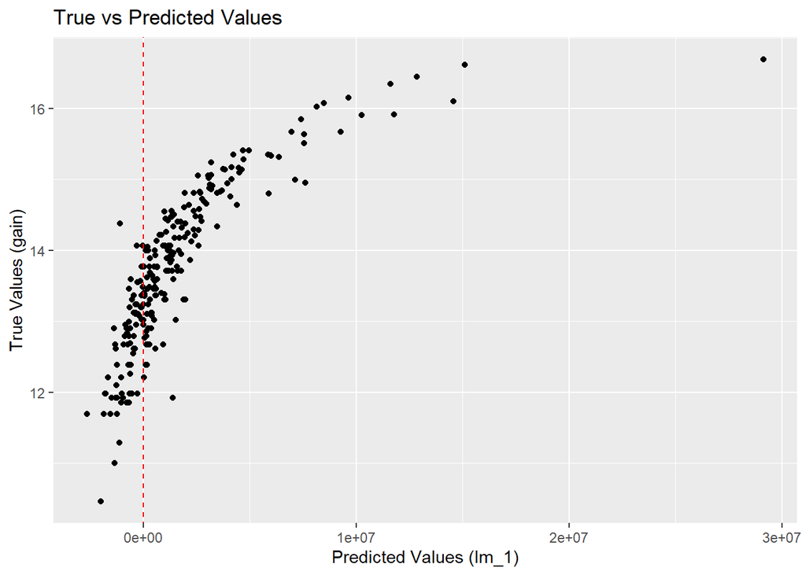

```r
ggplot(test_results, aes(x = lm_1, y = total_sales)) +
  geom_point() +
  geom_abline(intercept = 0, slope = 1, color = "red", linetype = "dashed") +  # Add a reference line (y = x)
  labs(title = "True vs Predicted Values",
       x = "Predicted Values (lm_1)",
       y = "True Values (gain)")
```

### 5.2 Model using the most correlated features

Now, we will only use the most correlated features. We have also added interactions.

```r
correlated_model = total_sales ~ tickets_sold:ticket_use + show_time + occu_perc:capacity

lm_tune <- train(correlated_model,
                 data = cineTrain_small,
                 method = "lm",
                 preProc=c('scale', 'center'),
                 trControl = ctrl)

test_results <- data.frame(total_sales = log(cineTest_small$total_sales))

test_results$lm_1 <- predict(lm_tune, cineTest_small)

observed = log(log(cineTest_small$total_sales))

x = postResample(pred = test_results$lm_1,  obs = observed)

results <- data.frame(Method= "correlated_features", RMSE = x[1], R2 = x[2], MAE = x[3], stringsAsFactors = FALSE)
#print(results)
```

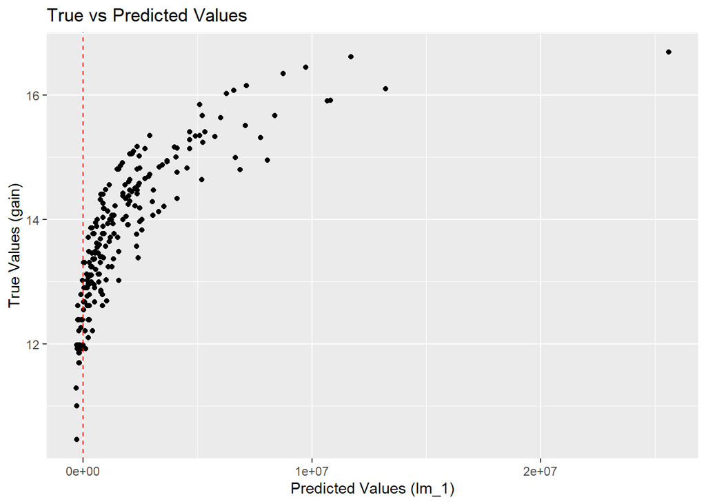

```r
ggplot(test_results, aes(x = lm_1, y = total_sales)) +
  geom_point() +
  geom_abline(intercept = 0, slope = 1, color = "red", linetype = "dashed") +  # Add a reference line (y = x)
  labs(title = "True vs Predicted Values",
       x = "Predicted Values (lm_1)",
       y = "True Values (gain)")
```

## 5. Statistical Learning Tools

Let’s use the caret package with CV.

```r
ctrl <- trainControl(method = "repeatedcv",
                     number = 5, repeats = 1)
```

### 5.1. Model selection

#### 5.1.1. Forward selection

The goal of forward selection is to iteratively add predictor variables to a model one at a time, selecting the variable that contributes the most to the model’s performance at each step. This process continues until a stopping criterion is met.

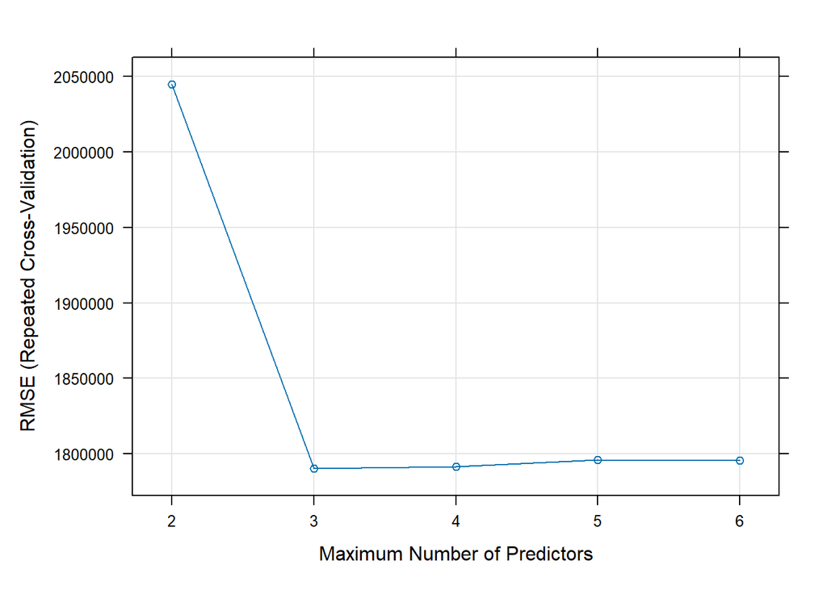

```r
Model_forw = total_sales ~ tickets_sold:ticket_use + show_time + occu_perc:capacity + ticket_price + month:quarter + log(ratio_used)

tune <- train(Model_forw, data = cineTrain_small,
                  method = "leapForward",
                  preProc=c('scale', 'center'),
                  tuneGrid = expand.grid(nvmax = 2:6), #for the hyperparam tuning of the method (defines the number of variables to consider)
                  trControl = ctrl)

plot(tune)
```

The plot suggests us to only keep the first 3 parameters, as after that we will not reduce the RMSE. Selected variables are ticket_price, tickets_sold:ticket_use and occu_perc:capacity.

```r
coef(tune$finalModel, tune$bestTune$nvmax)
```

```
##             (Intercept)            ticket_price tickets_sold:ticket_use
##               3511245.7                988004.3               2915269.7
##      occu_perc:capacity
##               8579472.6
```

```r
test_results$frw <- predict(tune, cineTest_small)
x= postResample(pred = test_results$frw,  obs = test_results$total_sales)

results2 <- c("Forward", x[1], x[2], x[3])

# Adding these results to the results table
results <- rbind(results, results2)
#print(results)
```

[figure not shown]

```r
qplot(test_results$frw, test_results$total_sales) +
  labs(title="Forward Regression Observed VS Predicted", x="Predicted", y="Observed") +
  lims(x = c(10, 15), y = c(10, 15)) +
  geom_abline(intercept = 0, slope = 1, colour = "blue") +
  theme_bw()
```

#### 5.1.2. Backward selection

We use the model that we defined before for the forward selection, but now the modeling process starts with a model that includes all predictor variables and iteratively removes the least significant variables one at a time. The goal is to simplify the model while retaining those variables that are most relevant to the response variable.

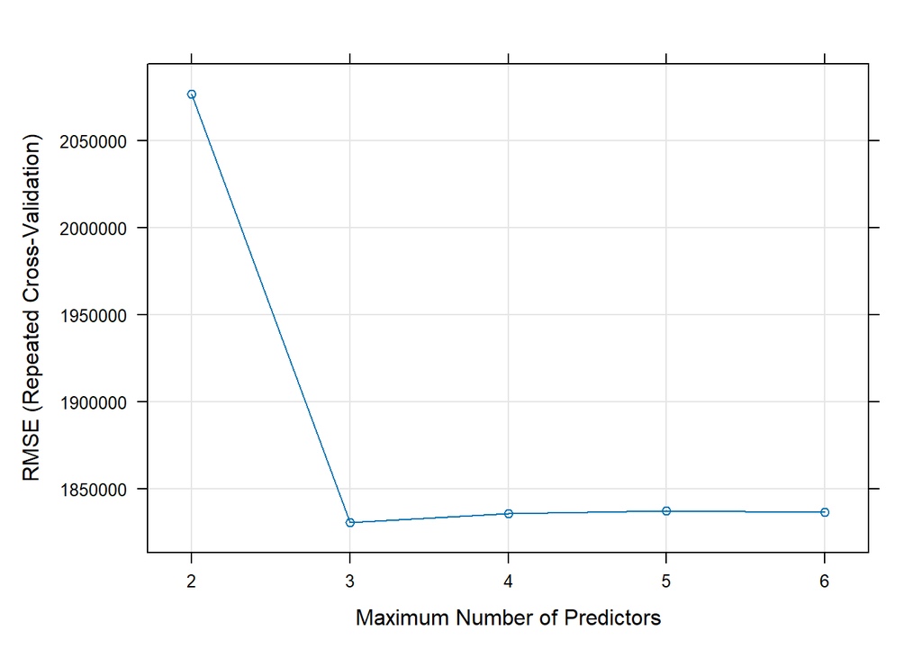

```r
back_tune <- train(Model_forw, data = cineTrain_small,
                   method = "leapBackward",
                   preProc=c('scale', 'center'),
                   tuneGrid = expand.grid(nvmax = 2:6),
                   trControl = ctrl)
plot(back_tune)
```

The plot suggests us to only keep the first 3 parameters, as after that we will not reduce the RMSE. Selected variables are ticket_price, tickets_sold:ticket_use and occu_perc:capacity.

```r
coef(back_tune$finalModel, back_tune$bestTune$nvmax)
```

```
##             (Intercept)            ticket_price tickets_sold:ticket_use
##               3511245.7                988004.3               2915269.7
##      occu_perc:capacity
##               8579472.6
```

```r
test_results$bw <- predict(back_tune, cineTest_small)

x = postResample(pred = test_results$bw,  obs = test_results$total_sales)

results3 <- c("Backward", x[1], x[2], x[3])

# Adding these results to the results table
results <- rbind(results, results3)
#print(results)
```

The backward model gives exactly the same results as the forward one, with the same error and R squared value.

[figure not shown]

```r
qplot(test_results$bw, test_results$total_sales) +
  labs(title="Backward Regression Observed VS Predicted", x="Predicted", y="Observed") +
  lims(x = c(10, 15), y = c(10, 15)) +
  geom_abline(intercept = 0, slope = 1, colour = "blue") +
  theme_bw()
```

#### 5.1.3. Stepwise selection

In stepwise selection, the process involves both forward and backward steps to iteratively add or remove variables from a model. We still use the model we created for forward selection.

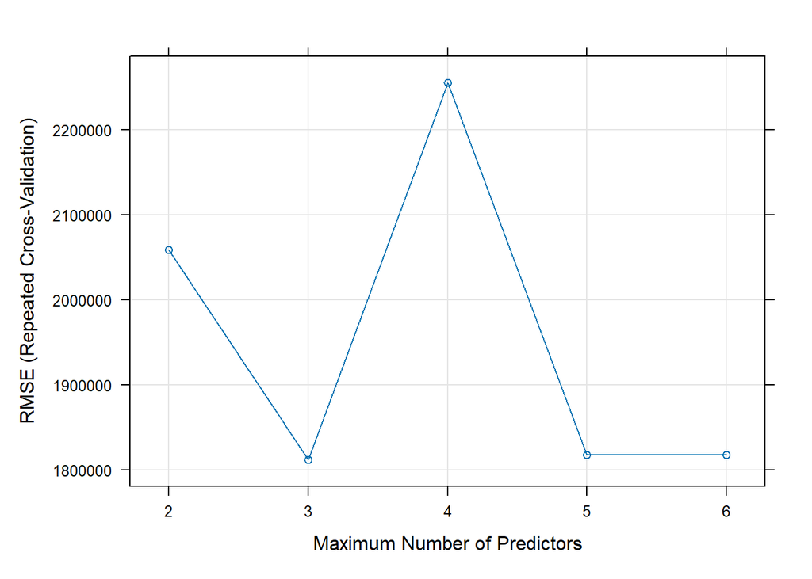

```r
step_tune <- train(Model_forw, data = cineTrain_small,
                   method = "leapSeq",
                   preProc=c('scale', 'center'),
                   tuneGrid = expand.grid(nvmax = 2:6),
                   trControl = ctrl)
plot(step_tune)
```

```r
# which variables are selected?
coef(step_tune$finalModel, step_tune$bestTune$nvmax)
```

```
##             (Intercept)            ticket_price tickets_sold:ticket_use
##               3511245.7                988004.3               2915269.7
##      occu_perc:capacity
##               8579472.6
```

[figure not shown]

```r
test_results$seq <- predict(step_tune, cineTest_small)

x = postResample(pred = test_results$seq,  obs = test_results$total_sales)

results4 <- c("Stepwise", x[1], x[2], x[3])

# Adding these results to the results table
results <- rbind(results, results4)
#print(results)

qplot(test_results$seq, test_results$total_sales) +
  labs(title="Stepwise Regression Observed VS Predicted", x="Predicted", y="Observed") +
  lims(x = c(10, 15), y = c(10, 15)) +
  geom_abline(intercept = 0, slope = 1, colour = "blue") +
  theme_bw()
```

The plot suggests us to only keep the first 3 parameters, as after that we will not reduce the RMSE. Selected variables are ticket_price, tickets_sold:ticket_use and occu_perc:capacity.

The step-wise model gives exactly the same results as the forward and the backward ones, with the same error and R squared value.

### 5.2. Regularization methods

#### 5.2.1. Ridge

It is a linear regression technique that introduces a penalty term to the linear regression cost function. The goal of ridge regression is to prevent over-fitting and improve the performance of the model, especially when there is multicollinearity among the predictor variables. The algorithm is extremely fast.

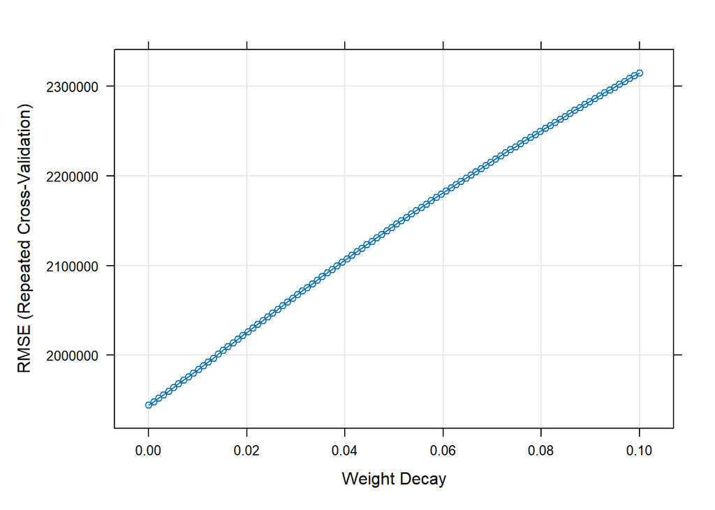

```r
# the grid for lambda
ridge_grid <- expand.grid(lambda = seq(0, .1, length = 100))

# train
ridge_tune <- train(Model_forw, data = cineTrain_small,
                    method='ridge',
                    preProc=c('scale','center'),
                    tuneGrid = ridge_grid,
                    trControl=ctrl)
plot(ridge_tune)
```

```r
# the best tune
ridge_tune$bestTune
```

```
##   lambda
## 1      0
```

```r
# prediction
test_results$ridge <- predict(ridge_tune, cineTest_small)

x = postResample(pred = test_results$ridge,  obs = test_results$total_sales)

results5 <- c("Ridge", x[1], x[2], x[3])

# Adding these results to the results table
results <- rbind(results, results5)
#print(results)
```

Its results are very similar to the previous models, but this one is easier to use.

#### 5.2.2. Lasso

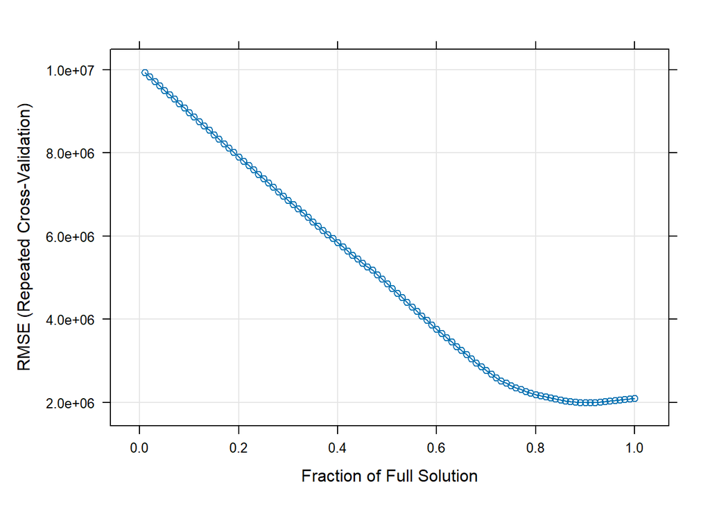

```r
lasso_grid <- expand.grid(fraction = seq(.01, 1, length = 100))

lasso_tune <- train(Model_forw, data = cineTrain_small,
                    method='lasso',
                    preProc=c('scale','center'),
                    tuneGrid = lasso_grid,
                    trControl=ctrl)
plot(lasso_tune)
```

```r
lasso_tune$bestTune
```

```
##    fraction
## 90      0.9
```

```r
test_results$lasso <- predict(lasso_tune, cineTest_small)

x = postResample(pred = test_results$lasso,  obs = test_results$total_sales)

results6 <- c("Lasso", x[1], x[2], x[3])

# Adding these results to the results table
results <- rbind(results, results6)
#print(results)
```

Results for the Lasso are also very similar to the previous ones.

#### 5.2.3. Elastic Net

The elastic net cost function is a linear combination of the L1 and L2 penalty terms, and it aims to achieve the benefits of variable selection (sparsity) from Lasso and the ability to handle correlated predictors from Ridge.

Let’s check the names for the hyper-parameters

```r
modelLookup('glmnet')
```

```
##    model parameter                    label forReg forClass probModel
## 1 glmnet     alpha        Mixing Percentage   TRUE     TRUE      TRUE
## 2 glmnet    lambda Regularization Parameter   TRUE     TRUE      TRUE
```

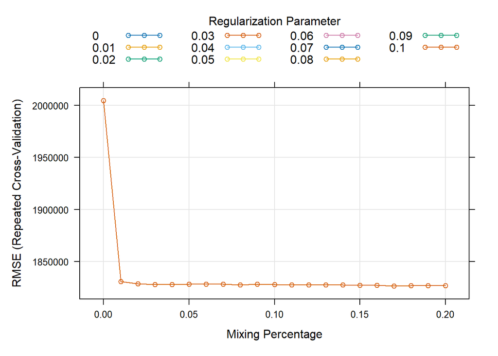

```r
elastic_grid = expand.grid(alpha = seq(0, .2, 0.01), lambda = seq(0, .1, 0.01))

glmnet_tune <- train(Model_forw, data = cineTrain_small,
                     method='glmnet',
                     preProc=c('scale','center'),
                     tuneGrid = elastic_grid,
                     trControl=ctrl)

plot(glmnet_tune)
```

```r
glmnet_tune$bestTune
```

```
##     alpha lambda
## 198  0.17    0.1
```

```r
test_results$glmnet <- predict(glmnet_tune, cineTest_small)

x = postResample(pred = test_results$glmnet,  obs = test_results$total_sales)

results7 <- c("Elastic Net", x[1], x[2], x[3])

# Adding these results to the results table
results <- rbind(results, results7)
#print(results)
```

Results are more or less the same again, but the RSME is a little bit smaller.

## 6. Machine Learning Tools

### 6.1. KNN

The algorithm makes predictions based on the average (for regression) of the k nearest neighbors in the feature space.

Let’s check the names for hyper-parameters

```r
modelLookup('kknn')
```

```
##   model parameter           label forReg forClass probModel
## 1  kknn      kmax Max. #Neighbors   TRUE     TRUE      TRUE
## 2  kknn  distance        Distance   TRUE     TRUE      TRUE
## 3  kknn    kernel          Kernel   TRUE     TRUE      TRUE
```

```r
# 3 hyper-parameters: kmax, distance, kernel
# kmax: number of neighbors considered
# distance: parameter of Minkowski distance (p in Lp)
# kernel: "rectangular" (standard unweighted knn), "triangular", "epanechnikov" (or beta(2,2)), "biweight" (or beta(3,3)), "tri- weight" (or beta(4,4)), "cos", "inv", "gaussian", "rank" and "optimal".
```

Because ML models are non-linear, we can use simpler formulas

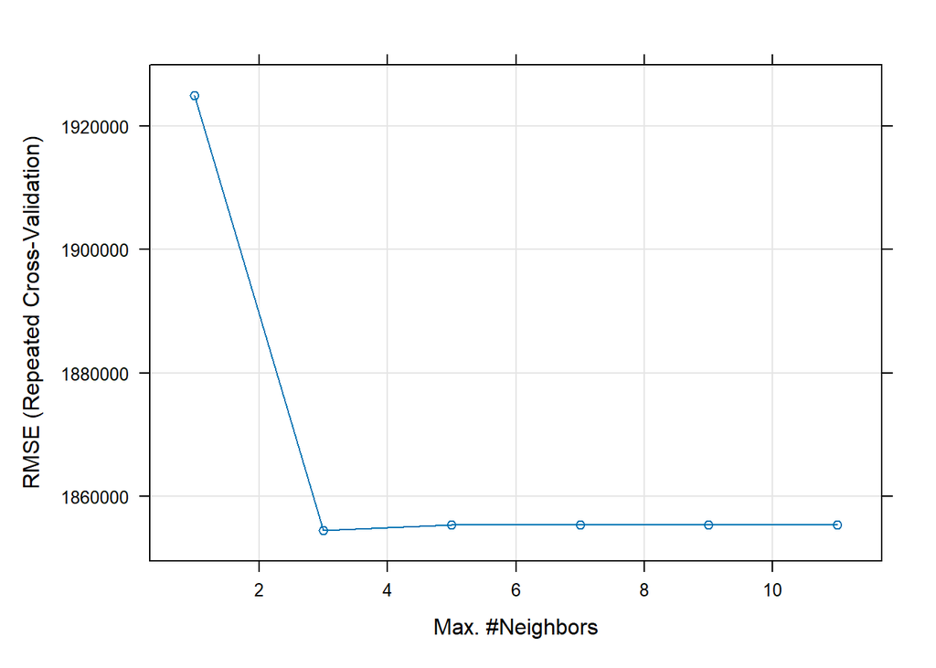

```r
knn_tune <- train(Model_forw, data = cineTrain_small,
                  method = "kknn",
                  preProc=c('scale','center'),
                  tuneGrid = data.frame(kmax=c(1,3,5,7,9,11),distance=2,kernel='optimal'),
                  trControl = ctrl)
plot(knn_tune)
```

```r
test_results$knn <- predict(knn_tune, cineTest_small)

x = postResample(pred = test_results$knn,  obs = test_results$total_sales)

results8 <- c("KNN", x[1], x[2], x[3])

# Adding these results to the results table
results <- rbind(results, results8)
#print(results)
```

With KNN the RMSE is lower, but so it is the R squared value.

### 6.2. Random Forests

It builds multiple decision trees during training and merges their predictions to improve the overall performance and robustness of the model.

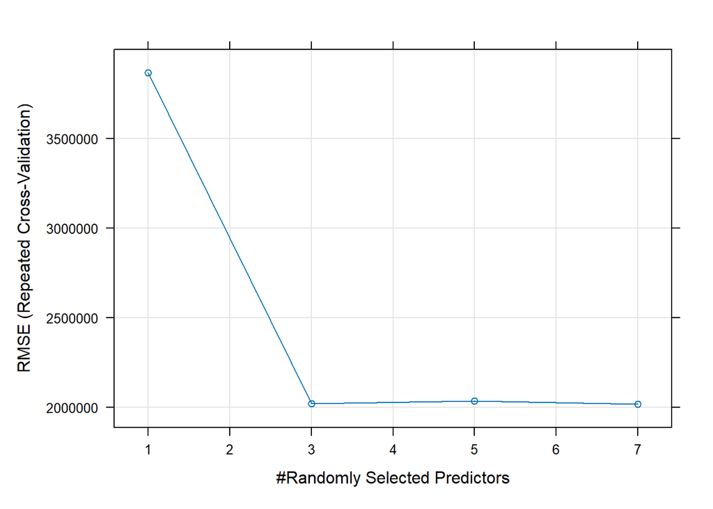

```r
rf_tune <- train(Model_forw, data = cineTrain_small,
                 method = "rf",
                 preProc=c('scale','center'),
                 trControl = ctrl,
                 ntree = 100,
                 tuneGrid = data.frame(mtry=c(1,3,5,7)),
                 importance = TRUE)

plot(rf_tune)
```

```r
test_results$rf <- predict(rf_tune, cineTest_small)

x = postResample(pred = test_results$rf,  obs = test_results$total_sales)

results9 <- c("Random Forest", x[1], x[2], x[3])

# Adding these results to the results table
results <- rbind(results, results9)
#print(results)
```

R squared is better than the previous one, but not as good as for forward, backward, step-wise, ridge, lasso and elastic nets techniques. Also, the RMSE is smaller than in the just mentioned tools but bigger than in KNN.

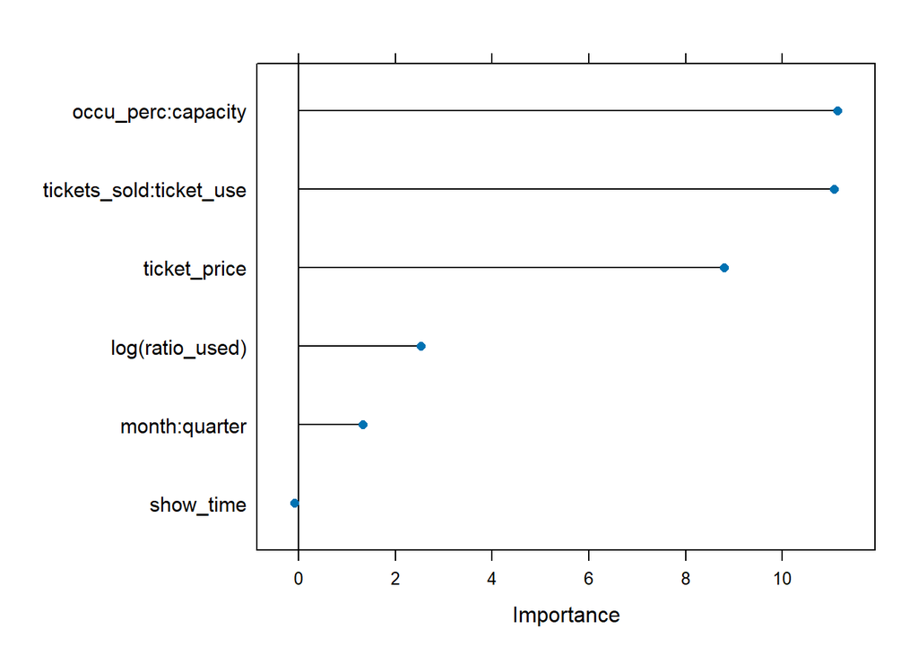

```r
library(pdp)

plot(varImp(rf_tune, scale = F), scales = list(y = list(cex = .95)))
```

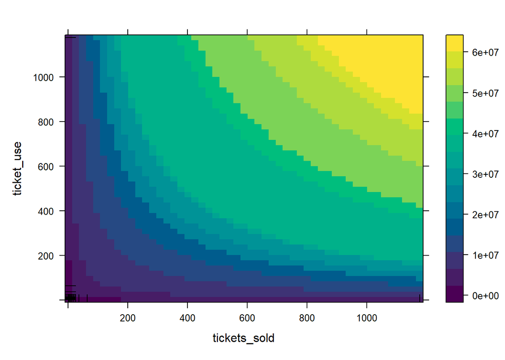

```r
partial(rf_tune, pred.var = c("tickets_sold", "ticket_use"), plot = TRUE, rug = TRUE)
```

As both variables increase, the model’s response tends to be higher. There is a positive interaction between the two variables.

### 6.3. Gradient Boosting

It builds a series of weak learners, typically decision trees, and combines their predictions to create a strong predictive model.

```r
xgb_tune <- train(
  Model_forw,
  data = cineTrain_small,
  method = "xgbTree",
  preProc = c('scale', 'center'),
  objective = "reg:squarederror",
  trControl = ctrl,
  tuneGrid = expand.grid(
    nrounds = c(100, 200),
    max_depth = c(3, 4),
    eta = c(0.01, 0.05, 0.1),
    gamma = c(0, 1),
    colsample_bytree = c(0.8, 1),
    min_child_weight = c(1),
    subsample = c(0.5, 0.8)
  ),
  verbosity = 0
)

test_results$xgb <- predict(xgb_tune, cineTest_small)

x <- postResample(pred = test_results$xgb, obs = test_results$total_sales)

results10 <- c("XGBoost", x[1], x[2], x[3])

# Adding these results to the results table
results <- rbind(results, results10)
#print(results)
```

Results are very similar to Random Forest

Finally, we will plot the importance of each variable: the most important one is tickets_sold:tickets_use (and the only one that this model considers important).

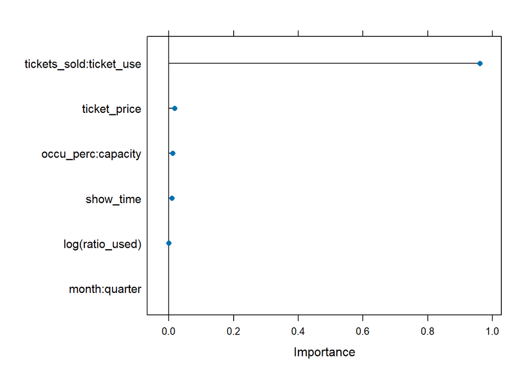

```r
plot(varImp(xgb_tune, scale = F), scales = list(y = list(cex = .95)))
```

Now, visualizing the partial dependence plots for the most important variable allows us to understand how this specific variable relates to the model’s response (partial dependence).

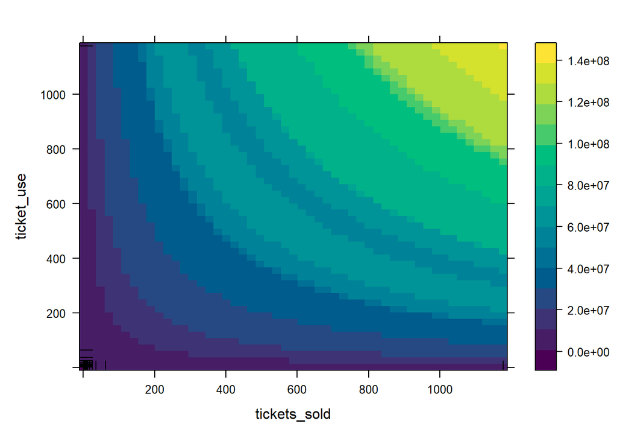

```r
partial(xgb_tune, pred.var = c("tickets_sold", "ticket_use"), plot = TRUE, rug = TRUE)
```

As both variables increase, the model’s response tends to be higher. There is a positive interaction between the two variables.

### 6.4 Neural Networks

There is no point in implementing Neural Networks here, as:

- Deep neural networks are computationally intensive and demand substantial computing resources, including processing power and memory. For relatively simple problems, the computational cost of training a neural network may outweigh the potential benefits in terms of accuracy improvement.
- Predicting cinema sales relies on variables that do not need the hierarchical and non-linear learning capabilities of neural networks, such as day of the week and season, simpler models can be equally effective.
- They are thought for image and video predictions specially.

Anyway,this would be the way of doing it:

```r
# nn_tune <- train(Model_forw, data = cineTrain_small,
#                  method = "neuralnet",
#                  preProc=c('scale','center'),
#                  trControl = ctrl,
#                  stepmax = 1e+06,
#                  tuneGrid = expand.grid(layer1 = c(2),
#     layer2 = c(1),
#     layer3 = c(0)))
#
# test_results$nn <- predict(nn_tune, cineTest_small)
#
# x= postResample(pred = test_results$nn,  obs = test_results$price)
#
# results11 <- c("Neural Networks", x[1], x[2], x[3])
#
# # Adding these results to the results table
# results <- rbind(results, results11)
# print(results)
```

```r
# plot(varImp(nn_tune, scale = F), scales = list(y = list(cex = .95)))
#
# partial(nn_tune, pred.var = c("tickets_sold", "ticket_use"), plot = TRUE, rug = TRUE)
```